## Instructions

The format for this lab is similar to the last one. I have a section here which loads in various libraries (if some are new, there will also be code to install them) and then loads a dataset of interest. Your goal is to predict the value of the third column (which will be missing on the test set) using the techniques we have learned so far. In this case, please restrict yourself to linear regressions, though you may now use multivariate models.

The lab should be written as short code snippets with surrounding text. The text should be in full sentences and should fully describe what and why you are running the code you are running. When there are results, you should also give a sentence or two describing them.

Make sure to include at a minimum several plots and justify why are picked the final model you are using.

You may not share code with other students prior to the submission of each lab. However, discussing the labs amongst other students is allowed. Also, copying and pasting my code from class or prior submissions you made is **not** considered plagiarism and is in fact highly encouraged. With permission, I may occasionally post student-solutions to past labs. These are also fair game for copying code from (though please do not excessively copy the expository text). If in doubt, please ask me before submitting results.

## Set up

Your first step should be to read in the following libraries:

```r
library(readr)
library(dplyr)
```

```r
library(ggplot2)
library(viridis)
```

And to load the wine dataset:

```r
wine <- read_csv("https://statsmaths.github.io/ml_data/wine.csv")
```

The dataset gives characteristics of various types of wine. Your goal is to use these to estimate the quality of the wine.

Your code and text should go in the section below (feel free to create sub-sections with the `###` command at the start of line, though please note that this is not required):

## Lab 03

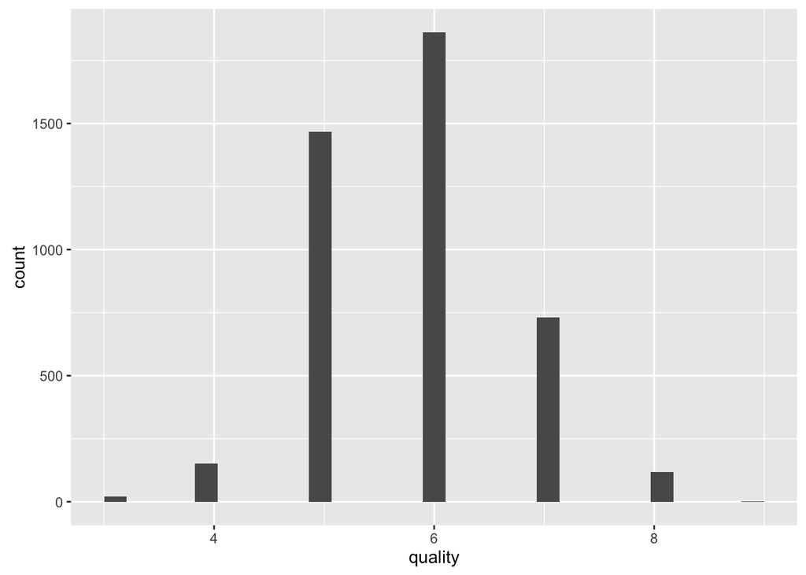

```r
#We can first start with looking at how wine quality is distributed
attach(wine)
qplot(quality, data=wine)
```

```r
#The range of scores is 3 to 9, with 6 being the most common, but with a large proportion of results below 6 (slight negatively skewed)
```

```r
#Before plotting more univariate series, it will be easier to create a correlation matrix with the continuous variables to determine what variables are highly correlated with wine

Corr_table <- data.frame(wine)
Corr_table$obs_id <- NULL
Corr_table$train_id <- NULL
Corr_table$red <- NULL

Corr_table <- na.omit(Corr_table)
cor(Corr_table)
```

```
##                          quality fixed_acidity volatile_acidity
## quality               1.00000000   -0.07309570      -0.25687151
## fixed_acidity        -0.07309570    1.00000000       0.21331684
## volatile_acidity     -0.25687151    0.21331684       1.00000000
## citric_acid           0.08155826    0.32633500      -0.38389975
## residual_sugar       -0.03924994   -0.11082852      -0.18956841
## chlorides            -0.19152563    0.28017389       0.37411234
## free_sulfur_dioxide   0.05349754   -0.27925384      -0.35832848
## total_sulfur_dioxide -0.05101667   -0.31264098      -0.42364415
## density              -0.30305939    0.44420806       0.27908258
## ph                    0.02511438   -0.26306306       0.27155235
## sulphates             0.02719291    0.29681762       0.24333011
## alcohol               0.44980241   -0.08426602      -0.03625514
##                       citric_acid residual_sugar   chlorides
## quality               0.081558264    -0.03924994 -0.19152563
## fixed_acidity         0.326334995    -0.11082852  0.28017389
## volatile_acidity     -0.383899753    -0.18956841  0.37411234
## citric_acid           1.000000000     0.14280158  0.04899634
## residual_sugar        0.142801580     1.00000000 -0.13712114
## chlorides             0.048996345    -0.13712114  1.00000000
## free_sulfur_dioxide   0.137960091     0.40033102 -0.19681906
## total_sulfur_dioxide  0.205502682     0.49729431 -0.27281202
## density               0.093136973     0.55763344  0.34108853
## ph                   -0.343240387    -0.26769772  0.03716943
## sulphates             0.062065833    -0.17713949  0.40750082
## alcohol              -0.008113914    -0.35692990 -0.24853642
##                      free_sulfur_dioxide total_sulfur_dioxide     density
## quality                       0.05349754          -0.05101667 -0.30305939
## fixed_acidity                -0.27925384          -0.31264098  0.44420806
## volatile_acidity             -0.35832848          -0.42364415  0.27908258
## citric_acid                   0.13796009           0.20550268  0.09313697
## residual_sugar                0.40033102           0.49729431  0.55763344
## chlorides                    -0.19681906          -0.27281202  0.34108853
## free_sulfur_dioxide           1.00000000           0.71754397  0.01805604
## total_sulfur_dioxide          0.71754397           1.00000000  0.03186598
## density                       0.01805604           0.03186598  1.00000000
## ph                           -0.15901119          -0.25967918  0.01635771
## sulphates                    -0.19536788          -0.27362502  0.26654399
## alcohol                      -0.17379306          -0.26457624 -0.67881372
##                               ph   sulphates      alcohol
## quality               0.02511438  0.02719291  0.449802410
## fixed_acidity        -0.26306306  0.29681762 -0.084266020
## volatile_acidity      0.27155235  0.24333011 -0.036255140
## citric_acid          -0.34324039  0.06206583 -0.008113914
## residual_sugar       -0.26769772 -0.17713949 -0.356929895
## chlorides             0.03716943  0.40750082 -0.248536416
## free_sulfur_dioxide  -0.15901119 -0.19536788 -0.173793058
## total_sulfur_dioxide -0.25967918 -0.27362502 -0.264576244
## density               0.01635771  0.26654399 -0.678813721
## ph                    1.00000000  0.18035579  0.119006647
## sulphates             0.18035579  1.00000000 -0.011858537
## alcohol               0.11900665 -0.01185854  1.000000000
```

```r
#In the correlation table, we see that the highest correlation between quality and another feature is alcohol (which may indicate we want to include this in our multivariate regression). Another thing to note is the negative correlation of quality and density.
```

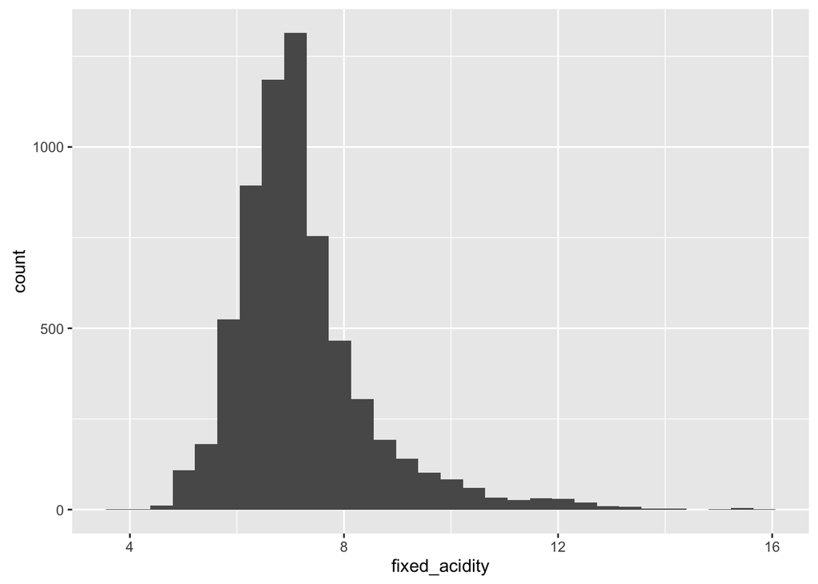

```r
#Now we can move on to plot the various univariate features: I have chosen to only include plots with some interesting features. Both fixed and volatile acidity seem to be very skewed and alcohol less so. The majority of values in density seem to be in a very tight range, although a few outliers could heavily influence our data.

qplot(fixed_acidity, data=wine)
```

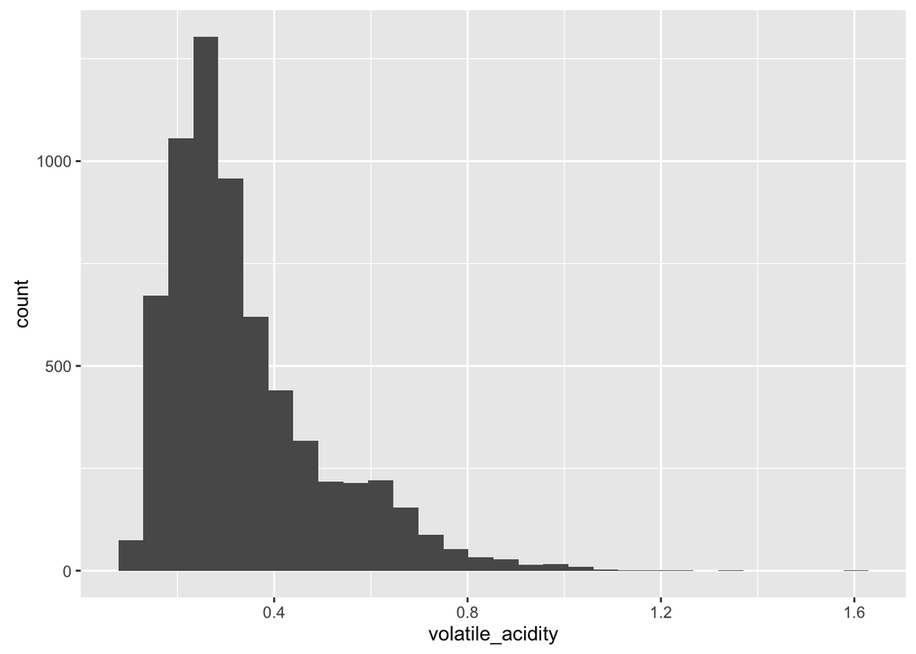

```r
qplot(volatile_acidity, data=wine)
```

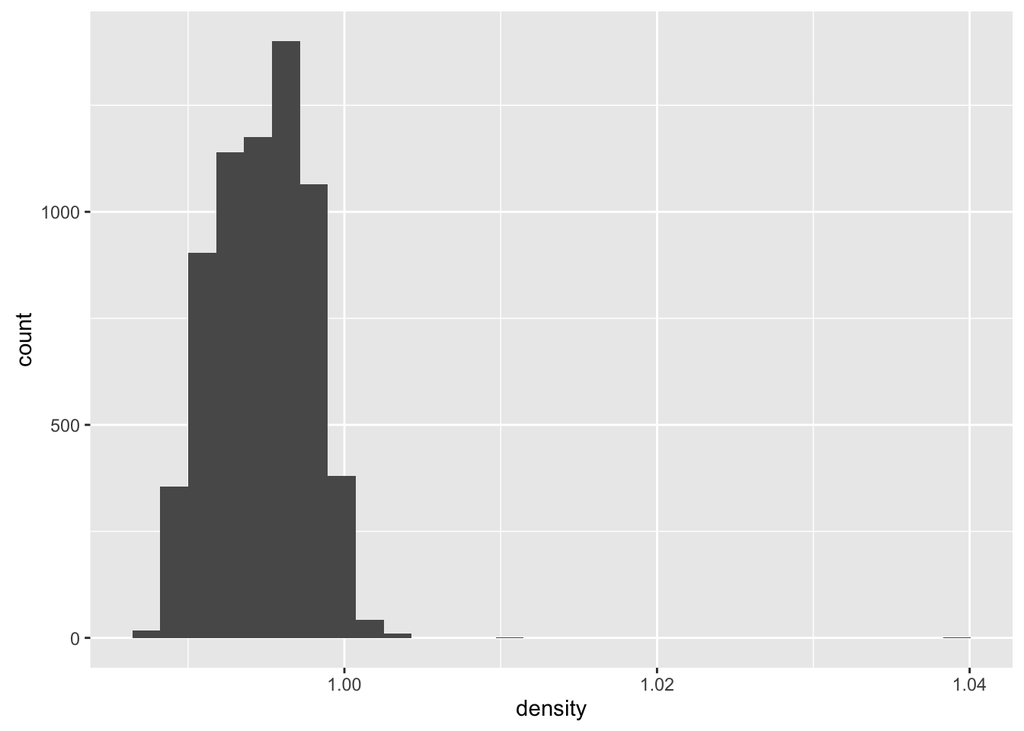

```r
qplot(density, data=wine)
```